# project2_jec4968

### Post Hoc test for Search Rate

```r
pairwise.t.test(open_policing$search_rate,open_policing$driver_race,
p.adj="none")
```

```
##
##  Pairwise comparisons using t tests with pooled SD
##
## data:  open_policing$search_rate and open_policing$driver_race
##
##          Black   Hispanic
## Hispanic 0.28    -
## White    1.2e-09 1.2e-12
##
## P value adjustment method: none
```

### Post Hoc test for Consent Search Rate

```r
pairwise.t.test(open_policing$consent_search_rate,open_policing$driver_race,
p.adj="none")
```

```
##
##  Pairwise comparisons using t tests with pooled SD
##
## data:  open_policing$consent_search_rate and open_policing$driver_race
##
##          Black   Hispanic
## Hispanic 0.17    -
## White    5.9e-07 2.7e-10
##
## P value adjustment method: none
```

### Post Hoc test for Arrest Rate

```r
pairwise.t.test(open_policing$arrest_rate,open_policing$driver_race,
p.adj="none")
```

```
##
##  Pairwise comparisons using t tests with pooled SD
##
## data:  open_policing$arrest_rate and open_policing$driver_race
##
##          Black   Hispanic
## Hispanic 1.7e-11 -
## White    7.3e-06 < 2e-16
##
## P value adjustment method: none
```

### Discussion

#### In total, 21 tests were performed; 1 MANOVA, 5 ANOVA, and 15 post hoc t tests. 0.05/21 = 0.002380952, which is the new level of significance that we will be looking at.

#### The MANOVA test results show significance(p val = 2.2e-16), so we should look at individual ANOVA’s for each numerical variable against driver_race to look for significance between those groups.

#### An ANOVA test for each of the 5 numerical variables showed significant except one variable, stop_rate. 3 post hoc tests where then ran for each of the 5 numerical variables tested to see which groups are significant whithin that numerical variable. But we only look at 4 of the numerical variables since one of them is not statistically significant.

#### In stops_per_year, there was significance seem between Whites and Blacks and Whites and Hispanics.

#### In search_rate, there was significance seem between Whites and Blacks and Whites and Hispanics.

#### In consent_search_rate, there was significance seem between Whites and Blacks and Whites and Hispanics.

#### In arrest_rate, there was significance seem between Whites and Blacks and Whites and Hispanics and Blacks and Hispanics.

#### In regards to the assumptions of the MANOVA, they most likely have been met, but there is a possibility that they weren’t. This is because the data that was collected by the project was a compilation of all the data that the project could get, and not random samples within all the traffic stops that were recorded by the state. The results of the post hoc tests do show that a lot of the results show significance of the numerical variables towards Whites versus Blacks and Hispanics which may show that there is some unnormality in the data. But there doesn’t seem to be any extreme outliers or extreme multicollinearity between any of the variables.

## 2) Randomization Test

### Finding Mean of Distribution

```r
open_policing%>%group_by(consent_search_bin)%>%summarize(m=mean(arrest_rate))%>%summarize(diff(m))
```

```
## # A tibble: 1 x 1
##   `diff(m)`
##       <dbl>
## 1   0.00509
```

### Random Distribution and p value Result

```r
rand_dist<-vector()
for(i in 1:5000){
new<-data.frame(arrestrate=sample(open_policing$arrest_rate),consentsearchratebin=open_policing$consent_search_bin)
rand_dist[i]<-mean(new[new$consentsearchratebin=="1",]$arrestrate)-
mean(new[new$consentsearchratebin=="0",]$arrestrate)
}

mean(rand_dist > 0.005091409)*2 #pvalue
```

```
## [1] 0.0324
```

### Visualization of the Random Distribution

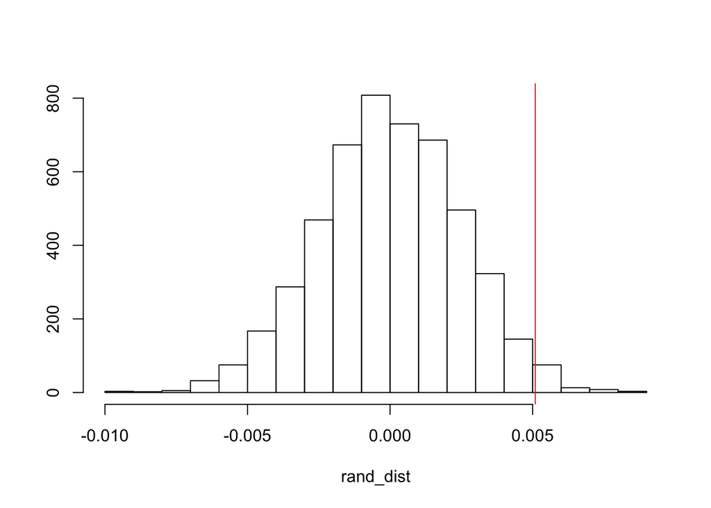

```r
{hist(rand_dist,main="",ylab=""); abline(v = 0.005091409    ,col="red")}
```

## 3) Linear Regression Model

### Interpret Coefficient Estimates

```r
open_policing$stop_rate_c <- open_policing$stop_rate - mean(open_policing$stop_rate)
fit_3<-lm(arrest_rate ~ consent_search_cat*stop_rate_c, data=open_policing)
summary(fit_3)
```

```
##
## Call:
## lm(formula = arrest_rate ~ consent_search_cat * stop_rate_c,
##     data = open_policing)
##
## Residuals:
##       Min        1Q    Median        3Q       Max
## -0.033275 -0.017784 -0.008089  0.008261  0.171565
##
## Coefficients:
##                                     Estimate Std. Error t value Pr(>|t|)
## (Intercept)                        0.0280696  0.0020211  13.888   <2e-16 ***
## consent_search_catyes              0.0046618  0.0024761   1.883   0.0602 .
## stop_rate_c                       -0.0011040  0.0009124  -1.210   0.2268
## consent_search_catyes:stop_rate_c -0.0024267  0.0024254  -1.001   0.3175
## ---
## Signif. codes:  0 '***' 0.001 '**' 0.01 '*' 0.05 '.' 0.1 ' ' 1
##
## Residual standard error: 0.0283 on 590 degrees of freedom
## Multiple R-squared:  0.0137, Adjusted R-squared:  0.008681
## F-statistic: 2.731 on 3 and 590 DF,  p-value: 0.04313
```

#### When stop_rate_c increases by 1, on average, the arrest_rate decreases by

0.0011040. When a search is executed with consent, on average, the arrest_rate increases by 0.0046618. Assuming there is consent to search, the effect of the stop_rate is lesser by -0.0024267 compared to there being no stop.

### Plot Regression

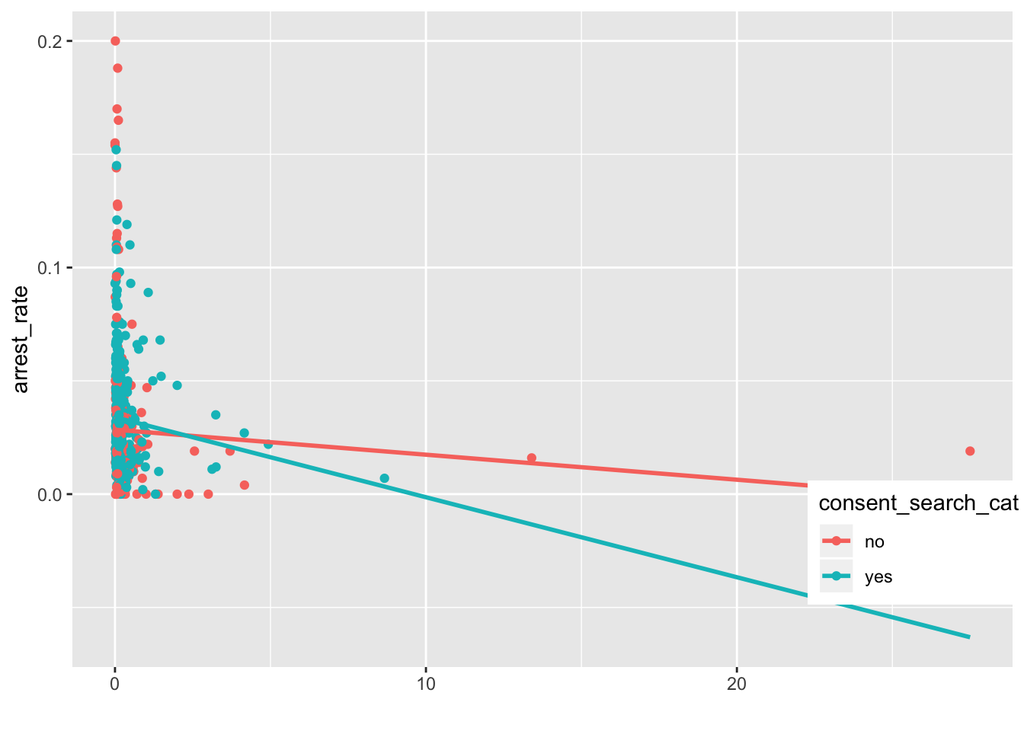

```r
ggplot(open_policing, aes(x=stop_rate, y=arrest_rate,group=consent_search_cat))+geom_point(aes(color=consent_search_cat))+
geom_smooth(method="lm",se=F,fullrange=T,aes(color=consent_search_cat))+
theme(legend.position=c(.9,.19))+xlab("")
```

### Check Assumptions

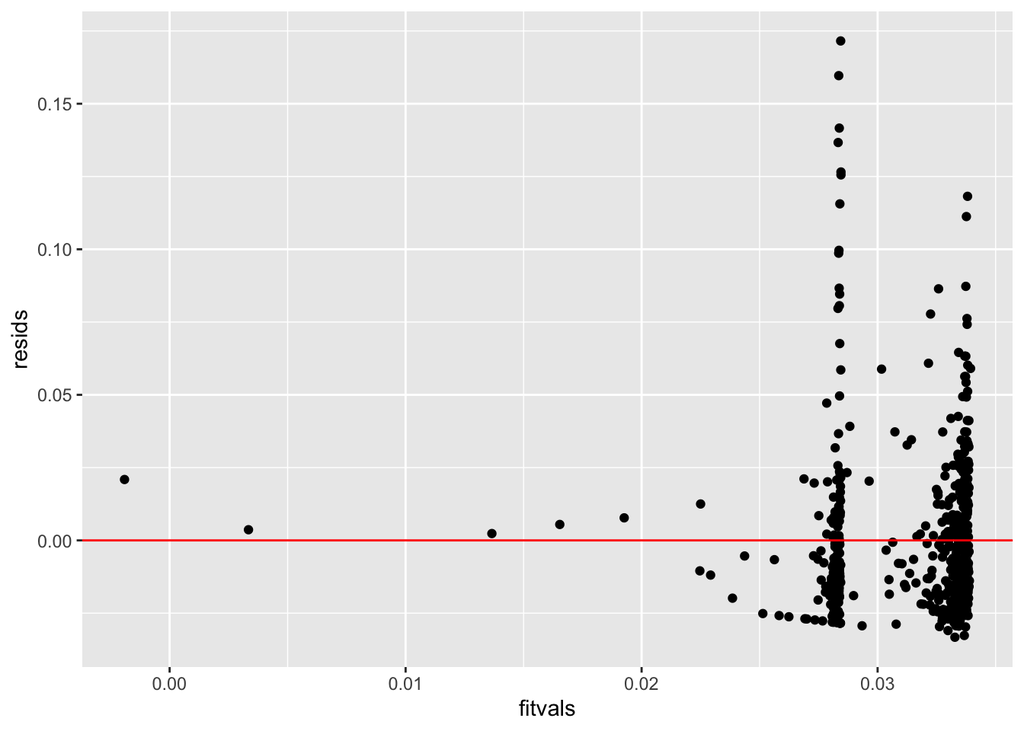

```r
resids<-fit_3$residuals
fitvals<-fit_3$fitted.values
ggplot()+geom_point(aes(fitvals,resids))+geom_hline(yintercept=0, color='red')
```

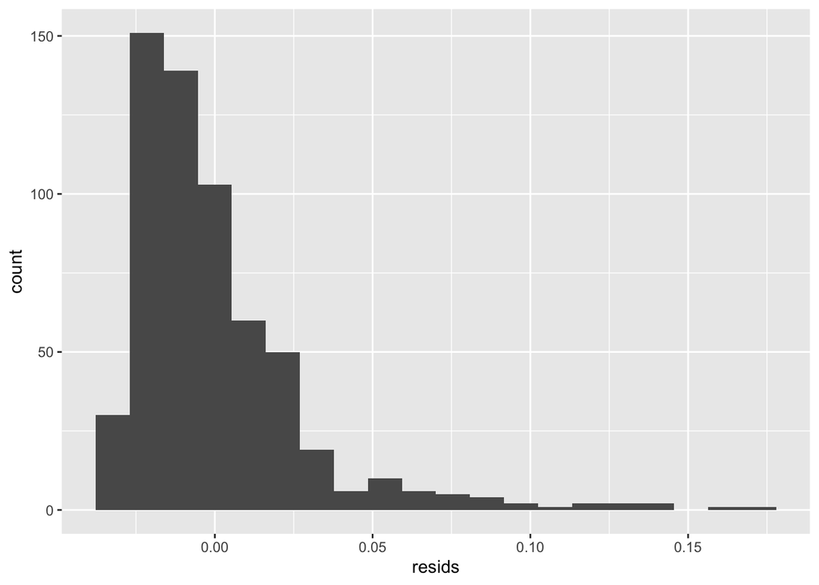

```r
ggplot()+geom_histogram(aes(resids), bins=20)
```

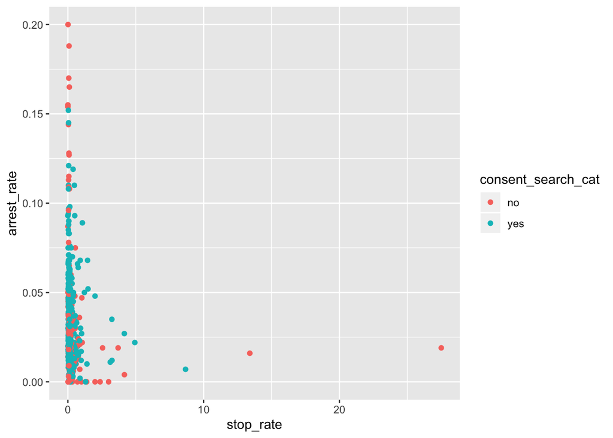

```r
ggplot(open_policing,aes(stop_rate,arrest_rate,color=consent_search_cat))+geom_point()
```